# ISLR_Chapter2

Carme Mias

02/05/2020

# Applied Exercises Chapter 2.

## Ex.8 p. 54

The College dataset.

First, explore the data:

```r
college_data <- read.csv('data/College.csv')
summary(college_data)
```

```
##                             X       Private        Apps           Accept
##  Abilene Christian University:  1   No :212   Min.   :   81   Min.   :   72
##  Adelphi University          :  1   Yes:565   1st Qu.:  776   1st Qu.:  604
##  Adrian College              :  1             Median : 1558   Median : 1110
##  Agnes Scott College         :  1             Mean   : 3002   Mean   : 2019
##  Alaska Pacific University   :  1             3rd Qu.: 3624   3rd Qu.: 2424
##  Albertson College           :  1             Max.   :48094   Max.   :26330
##  (Other)                     :771
##      Enroll       Top10perc       Top25perc      F.Undergrad
##  Min.   :  35   Min.   : 1.00   Min.   :  9.0   Min.   :  139
##  1st Qu.: 242   1st Qu.:15.00   1st Qu.: 41.0   1st Qu.:  992
##  Median : 434   Median :23.00   Median : 54.0   Median : 1707
##  Mean   : 780   Mean   :27.56   Mean   : 55.8   Mean   : 3700
##  3rd Qu.: 902   3rd Qu.:35.00   3rd Qu.: 69.0   3rd Qu.: 4005
##  Max.   :6392   Max.   :96.00   Max.   :100.0   Max.   :31643
##
##   P.Undergrad         Outstate       Room.Board       Books
##  Min.   :    1.0   Min.   : 2340   Min.   :1780   Min.   :  96.0
##  1st Qu.:   95.0   1st Qu.: 7320   1st Qu.:3597   1st Qu.: 470.0
##  Median :  353.0   Median : 9990   Median :4200   Median : 500.0
##  Mean   :  855.3   Mean   :10441   Mean   :4358   Mean   : 549.4
##  3rd Qu.:  967.0   3rd Qu.:12925   3rd Qu.:5050   3rd Qu.: 600.0
##  Max.   :21836.0   Max.   :21700   Max.   :8124   Max.   :2340.0
##
##     Personal         PhD            Terminal       S.F.Ratio
##  Min.   : 250   Min.   :  8.00   Min.   : 24.0   Min.   : 2.50
##  1st Qu.: 850   1st Qu.: 62.00   1st Qu.: 71.0   1st Qu.:11.50
##  Median :1200   Median : 75.00   Median : 82.0   Median :13.60
##  Mean   :1341   Mean   : 72.66   Mean   : 79.7   Mean   :14.09
##  3rd Qu.:1700   3rd Qu.: 85.00   3rd Qu.: 92.0   3rd Qu.:16.50
##  Max.   :6800   Max.   :103.00   Max.   :100.0   Max.   :39.80
##
##   perc.alumni        Expend        Grad.Rate
##  Min.   : 0.00   Min.   : 3186   Min.   : 10.00
##  1st Qu.:13.00   1st Qu.: 6751   1st Qu.: 53.00
##  Median :21.00   Median : 8377   Median : 65.00
##  Mean   :22.74   Mean   : 9660   Mean   : 65.46
##  3rd Qu.:31.00   3rd Qu.:10830   3rd Qu.: 78.00
##  Max.   :64.00   Max.   :56233   Max.   :118.00
##
```

We’ll turn the row names into a column called College.Name:

```r
rownames(college_data)=college_data[,1]
colnames(college_data)[1] <- "College.Name"
head(college_data)
```

```
##                                              College.Name Private Apps Accept
## Abilene Christian University Abilene Christian University     Yes 1660   1232
## Adelphi University                     Adelphi University     Yes 2186   1924
## Adrian College                             Adrian College     Yes 1428   1097
## Agnes Scott College                   Agnes Scott College     Yes  417    349
## Alaska Pacific University       Alaska Pacific University     Yes  193    146
## Albertson College                       Albertson College     Yes  587    479
##                              Enroll Top10perc Top25perc F.Undergrad P.Undergrad
## Abilene Christian University    721        23        52        2885         537
## Adelphi University              512        16        29        2683        1227
## Adrian College                  336        22        50        1036          99
## Agnes Scott College             137        60        89         510          63
## Alaska Pacific University        55        16        44         249         869
## Albertson College               158        38        62         678          41
##                              Outstate Room.Board Books Personal PhD Terminal
## Abilene Christian University     7440       3300   450     2200  70       78
## Adelphi University              12280       6450   750     1500  29       30
## Adrian College                  11250       3750   400     1165  53       66
## Agnes Scott College             12960       5450   450      875  92       97
## Alaska Pacific University        7560       4120   800     1500  76       72
## Albertson College               13500       3335   500      675  67       73
##                              S.F.Ratio perc.alumni Expend Grad.Rate
## Abilene Christian University      18.1          12   7041        60
## Adelphi University                12.2          16  10527        56
## Adrian College                    12.9          30   8735        54
## Agnes Scott College                7.7          37  19016        59
## Alaska Pacific University         11.9           2  10922        15
## Albertson College                  9.4          11   9727        55
```

Let’s have a look at the data in the first 10 columns:

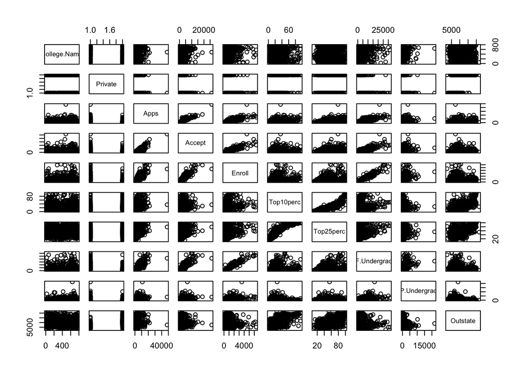

```r
pairs(college_data[,1:10])
```

And plot `Outstate` with `Private`:

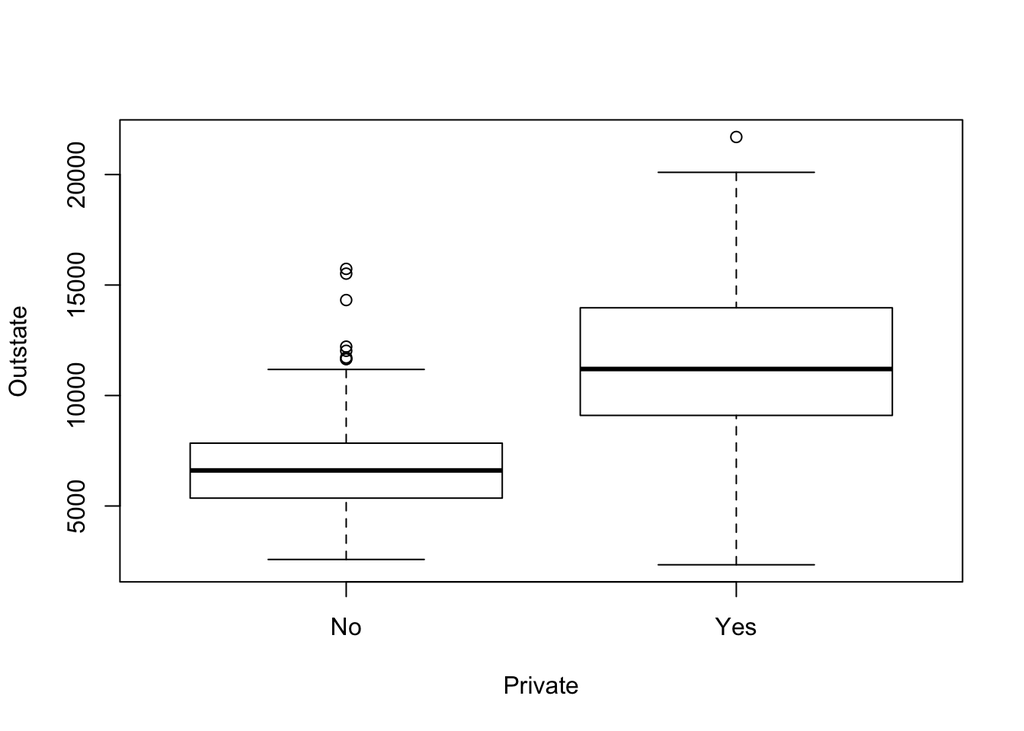

```r
invisible(attach(college_data))
plot(as.factor(Private), Outstate, ylab = "Outstate", xlab="Private")
```

The results show that private colleges take more out of state students than non-private colleges.

Add new column `Elite`, with “Yes”/“No” value to indicate whether at lest 50% of their students belong to the top 10% of their high school classes. Here’s how it can be done: 1. We’ll start by creating a vector “Elite” with as many “No” values as rows college_data has. 2. Then we use college_data’s `Top10perc` column as a filter to change the required vector values to “Yes”. 3. We use the resulting vector to create a new column. The vector name will automatically be used as the column name.

```r
Elite <- rep("No", nrow(college_data))
Elite[college_data$Top10perc > 50] <- "Yes"
college_data <- data.frame(college_data, Elite)
head(college_data)
```

```
##                                              College.Name Private Apps Accept
## Abilene Christian University Abilene Christian University     Yes 1660   1232
## Adelphi University                     Adelphi University     Yes 2186   1924
## Adrian College                             Adrian College     Yes 1428   1097
## Agnes Scott College                   Agnes Scott College     Yes  417    349
## Alaska Pacific University       Alaska Pacific University     Yes  193    146
## Albertson College                       Albertson College     Yes  587    479
##                              Enroll Top10perc Top25perc F.Undergrad P.Undergrad
## Abilene Christian University    721        23        52        2885         537
## Adelphi University              512        16        29        2683        1227
## Adrian College                  336        22        50        1036          99
## Agnes Scott College             137        60        89         510          63
## Alaska Pacific University        55        16        44         249         869
## Albertson College               158        38        62         678          41
##                              Outstate Room.Board Books Personal PhD Terminal
## Abilene Christian University     7440       3300   450     2200  70       78
## Adelphi University              12280       6450   750     1500  29       30
## Adrian College                  11250       3750   400     1165  53       66
## Agnes Scott College             12960       5450   450      875  92       97
## Alaska Pacific University        7560       4120   800     1500  76       72
## Albertson College               13500       3335   500      675  67       73
##                              S.F.Ratio perc.alumni Expend Grad.Rate Elite
## Abilene Christian University      18.1          12   7041        60    No
## Adelphi University                12.2          16  10527        56    No
## Adrian College                    12.9          30   8735        54    No
## Agnes Scott College                7.7          37  19016        59   Yes
## Alaska Pacific University         11.9           2  10922        15    No
## Albertson College                  9.4          11   9727        55    No
```

Let’s see it in a graph:

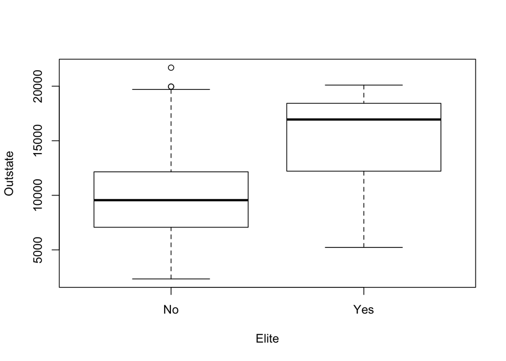

```r
plot(as.factor(Elite), Outstate, xlab="Elite", ylab="Outstate")
```

The results show that the elite colleges have far more out of state students than the non-elite colleges.

Finally, we’ll explore some of the numerical variables.

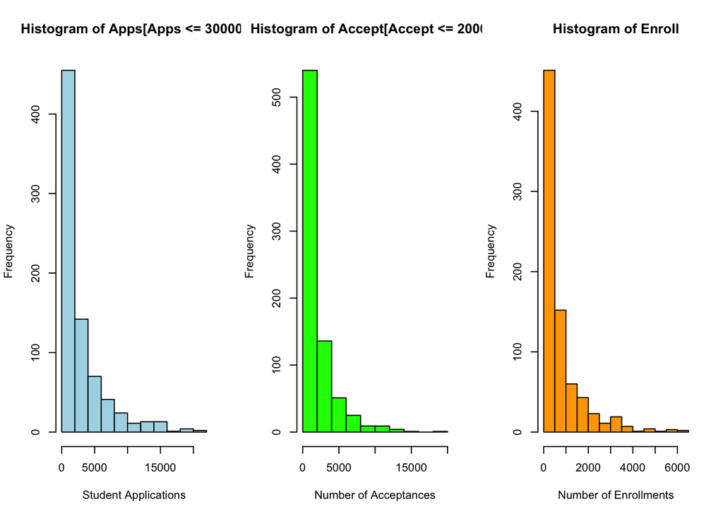

```r
op <- par(mfrow=c(1,3))
hist(Apps[Apps <= 30000], col = "lightblue", xlab = "Student Applications")
hist(Accept[Accept <=20000], col = "green", xlab = "Number of Acceptances")
hist(Enroll, col = "orange", xlab = "Number of Enrollments")
```

Let’s see how private/public and elite/non-ellite colleges compare in terms of the data explored above:

```r
ordered_by_top10perc <- college_data[order(-Top10perc),]
attach(ordered_by_top10perc)
```

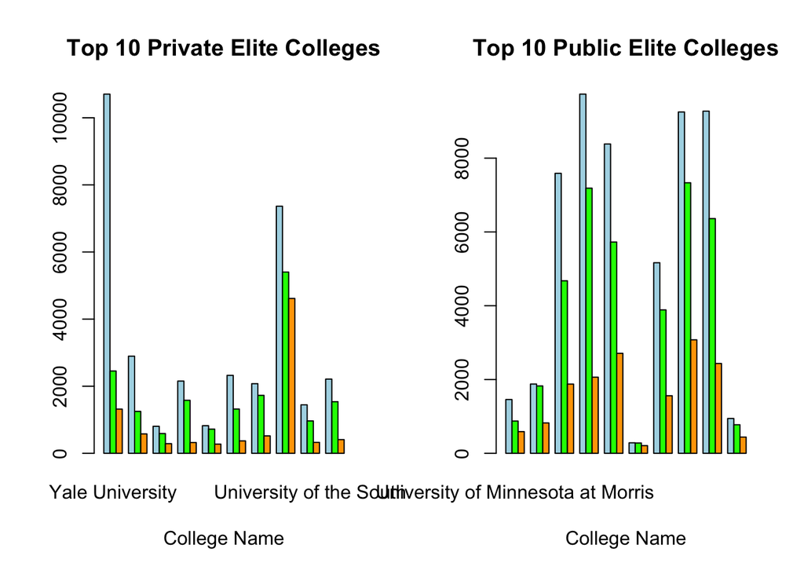

```r
top_10_private_elite <- head(ordered_by_top10perc[Private=="Yes" & Elite=="Yes",], 10)
top_10_public_elite <- head(ordered_by_top10perc[Private=="No" & Elite=="Yes",], 10)

op <- par(mfrow=c(1,2))
barplot(cbind(top_10_private_elite$Apps, top_10_private_elite$Accept, top_10_private_elite$Enroll) ~ top_10_private_elite$College.Name, beside=TRUE, col=c("lightblue", "green", "orange"), legend.text = TRUE, xlab="College Name", main = "Top 10 Private Elite Colleges")

barplot(cbind(top_10_public_elite$Apps, top_10_public_elite$Accept, top_10_public_elite$Enroll) ~ top_10_public_elite$College.Name, beside=TRUE, col=c("lightblue", "green", "orange"), legend.text = TRUE, xlab="College Name", main = "Top 10 Public Elite Colleges")
```

## Ex.10 p. 55

The Boston dataset. The dataset does not include town names.

```r
library(MASS)
str(Boston)
```

```
## 'data.frame':    506 obs. of  14 variables:
##  $ crim   : num  0.00632 0.02731 0.02729 0.03237 0.06905 ...
##  $ zn     : num  18 0 0 0 0 0 12.5 12.5 12.5 12.5 ...
##  $ indus  : num  2.31 7.07 7.07 2.18 2.18 2.18 7.87 7.87 7.87 7.87 ...
##  $ chas   : int  0 0 0 0 0 0 0 0 0 0 ...
##  $ nox    : num  0.538 0.469 0.469 0.458 0.458 0.458 0.524 0.524 0.524 0.524 ...
##  $ rm     : num  6.58 6.42 7.18 7 7.15 ...
##  $ age    : num  65.2 78.9 61.1 45.8 54.2 58.7 66.6 96.1 100 85.9 ...
##  $ dis    : num  4.09 4.97 4.97 6.06 6.06 ...
##  $ rad    : int  1 2 2 3 3 3 5 5 5 5 ...
##  $ tax    : num  296 242 242 222 222 222 311 311 311 311 ...
##  $ ptratio: num  15.3 17.8 17.8 18.7 18.7 18.7 15.2 15.2 15.2 15.2 ...
##  $ black  : num  397 397 393 395 397 ...
##  $ lstat  : num  4.98 9.14 4.03 2.94 5.33 ...
##  $ medv   : num  24 21.6 34.7 33.4 36.2 28.7 22.9 27.1 16.5 18.9 ...
```

```r
head(Boston)
```

```
##      crim zn indus chas   nox    rm  age    dis rad tax ptratio  black lstat
## 1 0.00632 18  2.31    0 0.538 6.575 65.2 4.0900   1 296    15.3 396.90  4.98
## 2 0.02731  0  7.07    0 0.469 6.421 78.9 4.9671   2 242    17.8 396.90  9.14
## 3 0.02729  0  7.07    0 0.469 7.185 61.1 4.9671   2 242    17.8 392.83  4.03
## 4 0.03237  0  2.18    0 0.458 6.998 45.8 6.0622   3 222    18.7 394.63  2.94
## 5 0.06905  0  2.18    0 0.458 7.147 54.2 6.0622   3 222    18.7 396.90  5.33
## 6 0.02985  0  2.18    0 0.458 6.430 58.7 6.0622   3 222    18.7 394.12  5.21
##   medv
## 1 24.0
## 2 21.6
## 3 34.7
## 4 33.4
## 5 36.2
## 6 28.7
```

We’ll do some initial explorations:

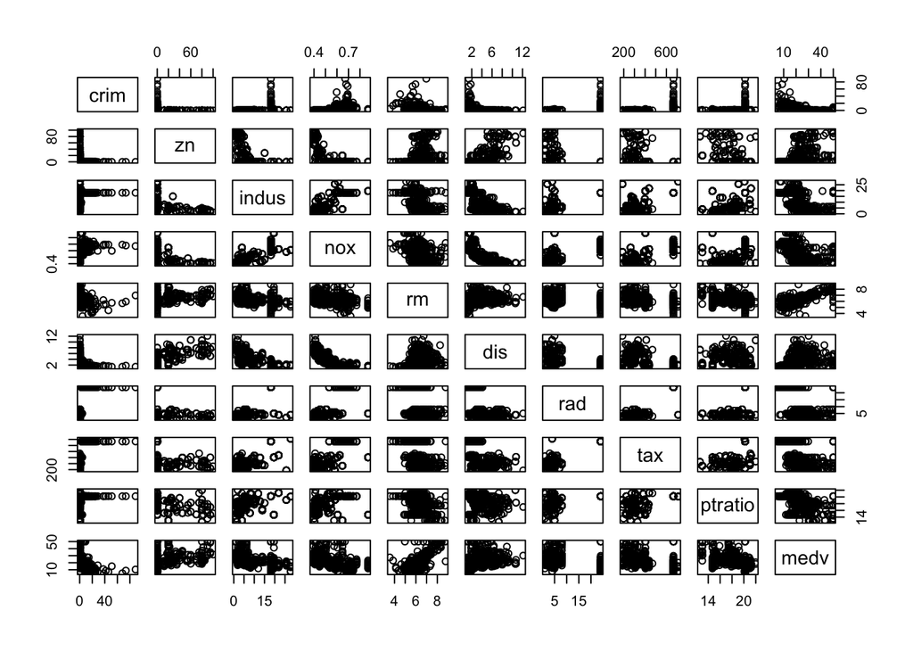

```r
pairs(Boston[,c("crim", "zn", "indus", "nox", "rm", "dis", "rad", "tax", "ptratio", "medv")])
```

Some interesting patterns seem to appear around Crime rates. Let’s expore them further:

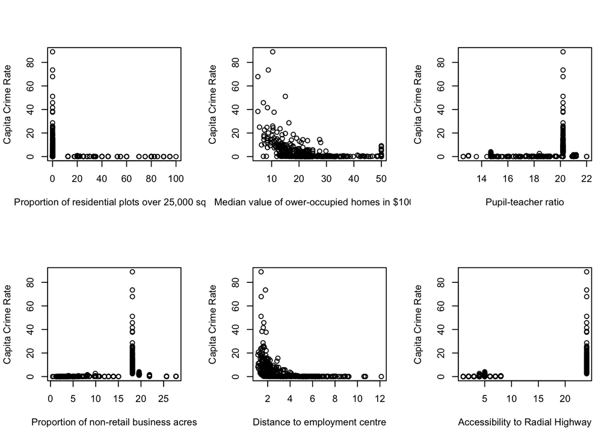

```r
attach(Boston)
op <- par(mfrow=c(2,3))
plot(x=zn, y=crim, xlab="Proportion of residential plots over 25,000 sq.ft", ylab="Capita Crime Rate")
plot(x=medv, y=crim, xlab="Median value of ower-occupied homes in $1000s", ylab="Capita Crime Rate")
plot(x=ptratio, y=crim, xlab="Pupil-teacher ratio", ylab="Capita Crime Rate")
plot(x=indus, y=crim, xlab="Proportion of non-retail business acres", ylab="Capita Crime Rate")
plot(x=dis, y=crim, xlab="Distance to employment centre", ylab="Capita Crime Rate")
plot(x=rad, y=crim, xlab="Accessibility to Radial Highway", ylab="Capita Crime Rate")
```

Also, some pollution and population level comparisons to re. distance to highway and work centre:

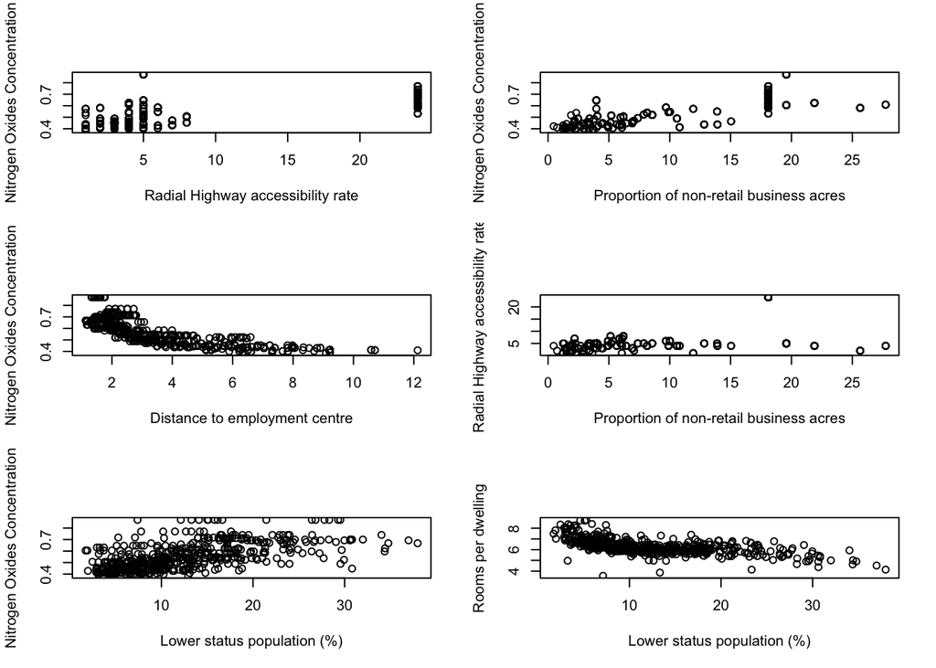

```r
op <- par(mfrow=c(3,2))
plot(x=rad, y=nox, xlab="Radial Highway accessibility rate", ylab="Nitrogen Oxides Concentration")
plot(x=indus, y=nox, xlab="Proportion of non-retail business acres", ylab="Nitrogen Oxides Concentration")
plot(x=dis, y=nox, xlab="Distance to employment centre", ylab="Nitrogen Oxides Concentration")
plot(x=indus, y=rad, xlab="Proportion of non-retail business acres", ylab="Radial Highway accessibility rate")
plot(x=lstat, y=nox, xlab="Lower status population (%)", ylab="Nitrogen Oxides Concentration")
plot(x=lstat, y=rm, xlab="Lower status population (%)", ylab="Rooms per dwelling")
```

Finally, a deeper look at the suburbs with the highest and lowest proportion of lowest status population:

```r
highest_lstat <- max(Boston[,"lstat"])
invisible(nrow(Boston[lstat==highest_lstat,]))
suburbA <- Boston[lstat==highest_lstat,]

lowest_lstat <- min(Boston[,"lstat"])
invisible(nrow(Boston[lstat==lowest_lstat,]))
suburbB <- Boston[lstat==lowest_lstat,]

print(paste0("SuburbA has the highest percentage of lower-status population at: ", highest_lstat,"%" ))
```

```
## [1] "SuburbA has the highest percentage of lower-status population at: 37.97%"
```

```r
print(paste0("SuburbB has lowest percentage of lower-status population at: ", lowest_lstat,"%" ))
```

```
## [1] "SuburbB has lowest percentage of lower-status population at: 1.73%"
```

Let’s prepare the data from those two suburbs before we start:

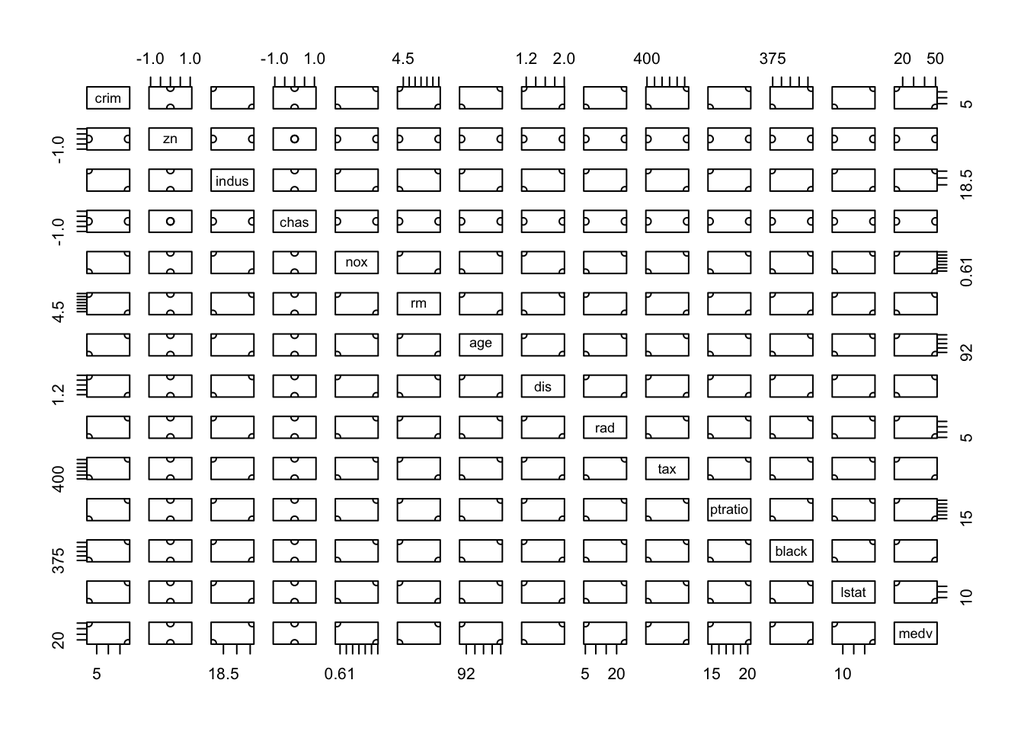

```r
highest_and_lowest <- Boston[Boston$lstat==lowest_lstat | Boston$lstat==highest_lstat,]
invisible(highest_and_lowest[order(lstat),])
rownames(highest_and_lowest)<-c("suburbB", "suburbA")
pairs(highest_and_lowest)
```

And now, we can plot the various variables:

```r
invisible(attach(highest_and_lowest))
```

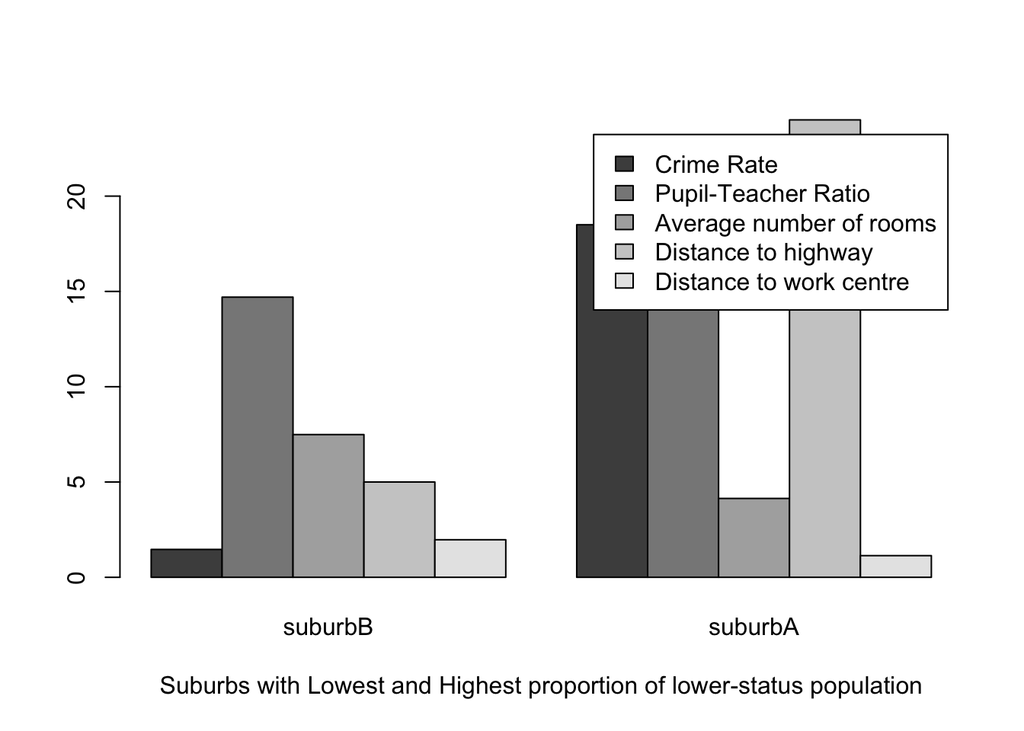

```r
# c("crim","indus", "nox", "rm", "age", "dis", "rad", "tax", "ptratio", "black", "medv")
barplot(cbind(crim, ptratio, rm, rad, dis) ~ lstat, beside=TRUE, names.arg = c("suburbB", "suburbA"), legend.text=c("Crime Rate", "Pupil-Teacher Ratio", "Average number of rooms", "Distance to highway", "Distance to work centre"), xlab = "Suburbs with Lowest and Highest proportion of lower-status population")
```

The variable relating to race seems to lack in detail but it is not shown to be a factor in the population status:

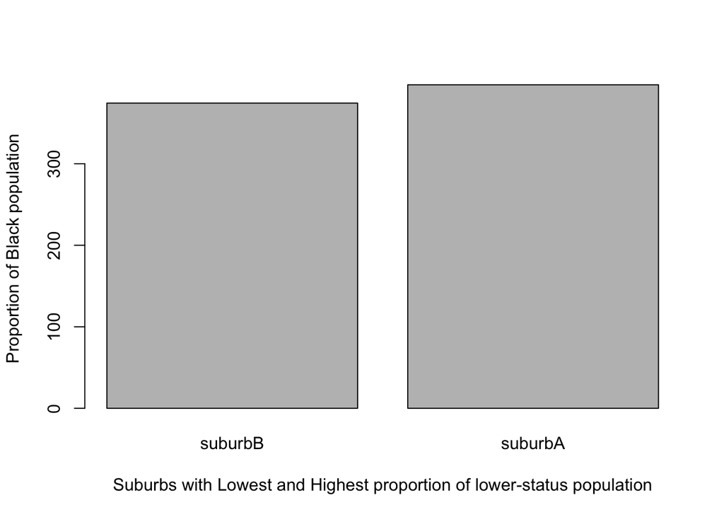

```r
barplot(black ~ lstat, ylab="Proportion of Black population", xlab = "Suburbs with Lowest and Highest proportion of lower-status population", names.arg = c("suburbB", "suburbA"))
```